# greenfleet_logistics

Ife Abe

2024-10-20

# Introduction

This project analyzes the potential benefits of transitioning GreenFleet Logistics’ truck fleet from diesel to electric vehicles. With a fleet of 100 trucks, comprising 70 diesel and 30 electric, we will evaluate the operational costs, maintenance expenses, and environmental impacts associated with each vehicle type.

Using R for calculations, we will:

- Calculate the total annual costs for both diesel and electric trucks, considering factors such as fuel efficiency, maintenance costs, and initial investments.
- Compare these costs to determine potential savings from switching entirely to electric trucks.

The goal is to provide insights into the financial viability of this transition, supporting GreenFleet’s commitment to sustainability and operational efficiency.

```r
# Load necessary libraries
library(ggplot2)
library(dplyr)

# Constants
diesel_price <- 4           # Price per gallon
electricity_price <- 0.10   # Price per kWh
annual_mileage <- 50000     # Mileage per truck
years <- 10                 # Set the analysis period
discount_rate <- 0.05       # Discount rate for NPV calculation

# Diesel Truck Data
diesel_trucks <- list(
  quantity = 70,
  maintenance_cost = 12000,
  fuel_efficiency = 6,      # miles per gallon
  purchase_price = 80000
)

# Electric Truck Data
electric_trucks <- list(
  quantity = 30,
  maintenance_cost = 8000,
  energy_efficiency = 2,    # miles per kWh
  purchase_price = 120000
)

# Calculate Diesel and Electric Annual Costs
diesel_fuel_cost_per_truck <- (annual_mileage / diesel_trucks$fuel_efficiency) * diesel_price
total_diesel_fuel_cost <- diesel_fuel_cost_per_truck * diesel_trucks$quantity
total_diesel_annual_cost <- total_diesel_fuel_cost + (diesel_trucks$maintenance_cost * diesel_trucks$quantity)

electric_energy_consumption_per_truck <- annual_mileage / electric_trucks$energy_efficiency
charging_cost_per_truck <- electric_energy_consumption_per_truck * electricity_price
total_electric_charging_cost <- charging_cost_per_truck * electric_trucks$quantity
total_electric_annual_cost <- total_electric_charging_cost + (electric_trucks$maintenance_cost * electric_trucks$quantity)

initial_investment <- (electric_trucks$purchase_price * electric_trucks$quantity) - (diesel_trucks$purchase_price * diesel_trucks$quantity)

annual_savings <- total_diesel_annual_cost - total_electric_annual_cost

# Output Results
total_diesel_annual_cost
```

```
## [1] 3173333
```

```r
total_electric_annual_cost
```

```
## [1] 315000
```

```r
initial_investment
```

```
## [1] -2e+06
```

```r
annual_savings
```

```
## [1] 2858333
```

## Net Present Value (NPV) Calculation

The NPV function computes the present value of cash flows over 10 years, accounting for the initial investment in electric trucks and the resulting annual savings.

```r
npv <- function(cash_flows, discount_rate) {
  sum(cash_flows / (1 + discount_rate)^(0:(length(cash_flows)-1)))
}

# Cash flows over the analysis period
cash_flows <- rep(annual_savings, years)
cash_flows[1] <- cash_flows[1] - initial_investment  # Include initial investment in the first year

npv_result <- npv(cash_flows, discount_rate)

npv_result
```

```
## [1] 25174857
```

## Break-Even Analysis

The code identifies the year in which cumulative savings from operating electric trucks surpass the initial investment, indicating that the switch becomes financially beneficial within the first year of operation. This means that GreenFleet Logistics will recoup its initial investment through savings generated from lower operational costs almost immediately.

```r
break_even_years <- which(cumsum(rep(annual_savings, years)) >= initial_investment)[1]  # First year when cumulative savings exceed investment
```

## Scenario Analysis

This part of the code tests different diesel price scenarios to observe how fluctuating prices impact the annual savings from electric trucks.

```r
# Scenario Analysis (example: fluctuating diesel prices)
scenario_results <- data.frame()
for (price in seq(3, 5, by = 0.5)) {
  diesel_price <- price
  diesel_fuel_cost_per_truck <- (annual_mileage / diesel_trucks$fuel_efficiency) * diesel_price
  total_diesel_fuel_cost <- diesel_fuel_cost_per_truck * diesel_trucks$quantity
  total_diesel_annual_cost <- total_diesel_fuel_cost + (diesel_trucks$maintenance_cost * diesel_trucks$quantity)

  annual_savings <- total_diesel_annual_cost - total_electric_annual_cost
  scenario_results <- rbind(scenario_results, data.frame(diesel_price = price, annual_savings = annual_savings))
}

annual_savings
```

[output not shown]

```
## [1] 3441667
```

## Visualization:

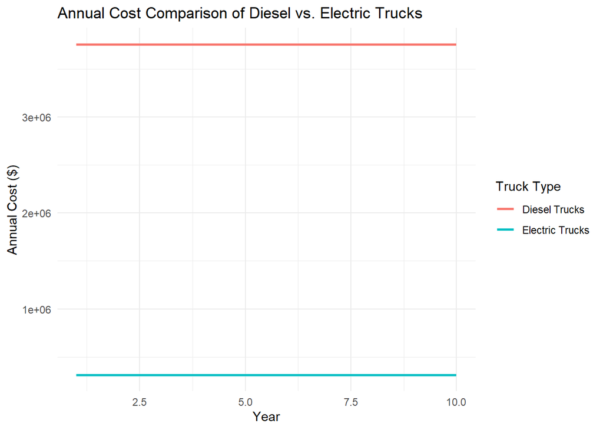

```r
# Visualization of Cost Comparison and Savings
cost_data <- data.frame(
  Year = 1:years,
  DieselCost = rep(total_diesel_annual_cost, years),
  ElectricCost = rep(total_electric_annual_cost, years)
)

ggplot(cost_data, aes(x = Year)) +
  geom_line(aes(y = DieselCost, color = "Diesel Trucks"), linewidth = 1) +  # Use linewidth instead of size
  geom_line(aes(y = ElectricCost, color = "Electric Trucks"), linewidth = 1) +  # Use linewidth instead of size
  labs(title = "Annual Cost Comparison of Diesel vs. Electric Trucks",
       x = "Year",
       y = "Annual Cost ($)",
       color = "Truck Type") +
  theme_minimal()
```

## Emission Reductions Visualization:

The bar chart compares the annual emissions of diesel and electric trucks, highlighting the significant reduction in emissions achieved by switching to electric vehicles.

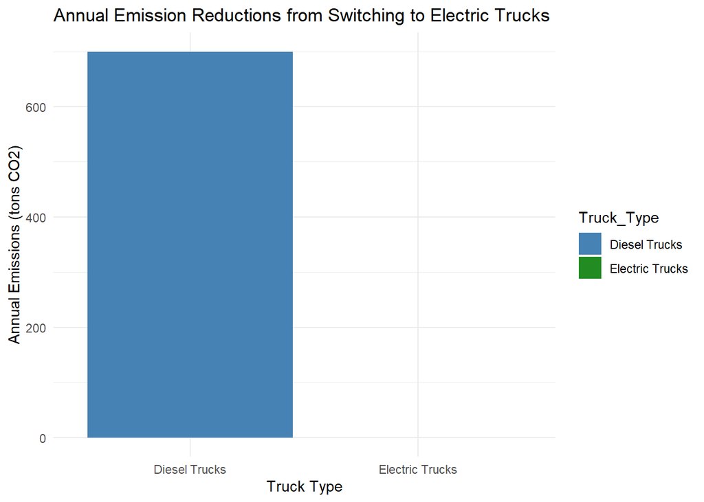

```r
# Emission Data
diesel_emission_rate <- 10  # tons CO2 per truck per year
electric_emission_rate <- 0  # electric trucks are assumed to have zero emissions

# Create a data frame for emissions
emission_data <- data.frame(
  Truck_Type = c("Diesel Trucks", "Electric Trucks"),
  Annual_Emissions = c(diesel_emission_rate * diesel_trucks$quantity, electric_emission_rate * electric_trucks$quantity)
)

# Visualization of Emission Reductions
ggplot(emission_data, aes(x = Truck_Type, y = Annual_Emissions, fill = Truck_Type)) +
  geom_bar(stat = "identity") +
  labs(title = "Annual Emission Reductions from Switching to Electric Trucks",
       x = "Truck Type",
       y = "Annual Emissions (tons CO2)") +
  theme_minimal() +
  scale_fill_manual(values = c("steelblue", "forestgreen"))
```

## Total Savings and Break-Even Point Visualization:

The line chart shows cumulative savings over time, with a dashed line indicating the break-even point (where cumulative savings equal zero). A green point marks the exact year when savings surpass the initial investment.

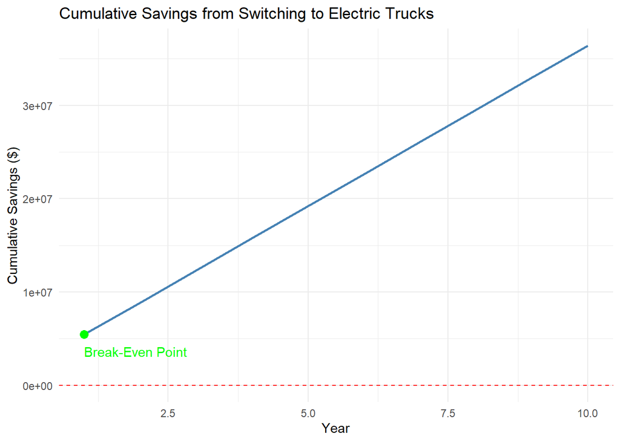

```r
# Create a data frame for cumulative savings over years
cumulative_savings <- cumsum(rep(annual_savings, years)) - initial_investment  # Adjust first year for initial investment
cumulative_data <- data.frame(
  Year = 1:years,
  Cumulative_Savings = cumulative_savings
)

# Visualization of Total Savings and Break-Even Point
ggplot(cumulative_data, aes(x = Year, y = Cumulative_Savings)) +
  geom_line(color = "steelblue", size = 1) +
  geom_hline(yintercept = 0, linetype = "dashed", color = "red") +
  geom_point(data = cumulative_data[cumulative_data$Cumulative_Savings >= 0, ][1, ], aes(x = Year, y = Cumulative_Savings), color = "green", size = 3) +
  labs(title = "Cumulative Savings from Switching to Electric Trucks",
       x = "Year",
       y = "Cumulative Savings ($)") +
  theme_minimal() +
  annotate("text", x = 1, y = max(cumulative_data$Cumulative_Savings) * 0.1, label = "Break-Even Point", color = "green", hjust = 0)
```